# Script No. 1

Marlene Kammerer

05 September 2023

# Getting started with network analysis in R

## Tutorial

### Content

- Load packages
- Load the network data
- Creating network objects
- Assigning attributes
- Network census (Identifying basic network configurations)

### Packages

In R, many roads lead to Rome! Consequently, there are several different packages with which you can do similar things.

For network analysis, this is certainly a good selection of packages!

**igraph**: https://igraph.org/r/

**statnet**: https://cran.r-project.org/web/packages/statnet/index.html; http://statnet.org/

**tidygraph**: https://CRAN.R-project.org/package=tidygraph

**ggraph**: https://cran.r-project.org/web/packages/ggraph/index.html

**Tutorial**: http://www.sthda.com/english/articles/33-social-network-analysis/136-network-analysis-and-manipulation-using-r/

### Install & load packages

In this first tutorial, we work with `igraph` only.

To install igraph, you can call `install.packages("igraph")`. As you know, you only have to install the package once. Igraph is already installed on my computer, so I hash-tagged the code line. But each time you work with a package you have to load it using `library(igraph)`.

```r
# install.packages("igraph") # to install the package
library(igraph) # to load the package
```

### Load the network data

In this first tutorial, we work with political network data from the US. We first load the network data into our Global Environment. Can you follow my steps?

For more information on the data you may have a look at ([Kammerer et al. 2021]https://onlinelibrary.wiley.com/doi/10.1111/psj.12422)

```r
## Attributes

att.usa <- read.csv2("Data/usa_attributes.csv", header=TRUE)

## Collaboration network

coll.usa <- read.csv2("Data/usa_collaboration.csv", header=TRUE)
rownames(coll.usa) <- coll.usa$ID
coll.usa$ID <- NULL

## Influence network

inf.usa <- read.csv2("Data/usa_influence.csv", header = TRUE, stringsAsFactors=FALSE)
rownames(inf.usa) <- inf.usa $ID
inf.usa$ID <- NULL

## Scientific information network

sci.usa <- read.csv2("Data/scientific-information_USA.csv", header = TRUE, stringsAsFactors=FALSE)
rownames(sci.usa) <- sci.usa$ID
sci.usa$ID <- NULL
```

### Explore data sets

Now, look at the data sets and try to make sense of them, based on what we have learnt about networks so far. What do you see? What is unclear?

Don’t be shocked if this is all Greek to you. We will get there. For now, the goal is to get used to handling this kind of data.

Please note, there are many way to display network data, for example based on edge-lists, instead of matrix notation. For now, we work with .csv files in (one-mode) matrix notation.

```r
View(att.usa)
View(coll.usa)
View(inf.usa)
View(sci.usa)
```

### Create network objects

Now, we have loaded the network data into our Global Environment. We have made sure that the different networks all have the same dimensions and are read in correctly. Now, we need to transform the network data into network (or graph objects).

#### First: Create matrices from data frames (only for “networks”)

```r
coll.mat <- as.matrix(coll.usa)
inf.mat <- as.matrix(inf.usa)
sci.mat <- as.matrix(sci.usa)

# How to deal with NAs?? For the moment, we will recode them to 0. But, at later points we also discuss different strategies for treating NAs.

coll.mat[is.na(coll.mat)] <- 0
inf.mat[is.na(inf.mat)] <- 0
sci.mat[sci.mat == 98] <- 0
```

#### Second: Create network object and visualize it in a first very simple plot

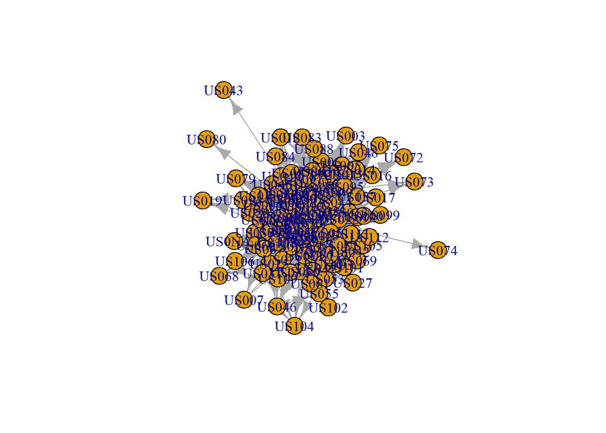

```r
coll.mat <- as.matrix(coll.usa)
coll.net <- graph.adjacency(coll.mat, mode="directed", diag=FALSE)
plot(coll.net)
```

Not very informative yet, right?! In the following weeks, you will learn how to analyse such networks and to make use of them to understand political phenomena.

### Explore network

In the following, we will do some basic analysis… Do you understand what all these statistics mean??

```r
# number of nodes and edges

vcount(coll.net)
```

```
## [1] 113
```

```r
ecount(coll.net)
```

```
## [1] 1269
```

```r
# cliques

table(sapply(cliques(coll.net), length))
```

```
##
##    1    2    3    4    5    6    7    8    9   10
##  113 1110 4016 7276 7577 4872 1992  512   77    5
```

```r
# dyads

dyad.census(coll.net)
```

```
## $mut
## [1] 159
##
## $asym
## [1] 951
##
## $null
## [1] 5218
```

```r
# triads

triad.census(coll.net)
```

```
##  [1] 140756  59411   8155  10235   2524   3084   1031   4461   1642     36
## [11]    463    285   1220    248    432    153
```

```r
# connectivity and paths

is.connected(coll.net)
```

```
## [1] TRUE
```

```r
# components (not really useful here)

comps <- decompose.graph(coll.net)
table(sapply(comps, vcount))
```

```
##
## 113
##   1
```

```r
# average path length

average.path.length(coll.net)
```

```
## [1] 1.996868
```

```r
diameter(coll.net)
```

```
## [1] 4
```

```r
# is this network very connected?
```

### Add attributes

Lastly, we add some attribute to the network, here the **actor type** … we will learn more about this in Session 3.

```r
att.usa$OT_BIG <- as.character(att.usa$OT_BIG)
V(coll.net)$actorType <- att.usa$OT_BIG

# list.vertex.attributes(coll.net)
```

## Exercises No. 1

1. Transform the **influence** matrix and the **science** matrix into igraph objects (i.e. igraph adjacency matrix).
2. Describe in your own words **what these networks reflect**, i.e. what are the ties? How are the three networks linked (collaboration, influence and science)?
3. Which network has more **asymmetric dyads** and which more **mutual dyads** - the science network, the influence network, or the collaboration network? What does this mean?
4. What is the **average path length** per network? What is the **diameter**? Are there differences between the networks? What does this imply?
5. Look at the `att.usa` data frame and try to understand what all these variables mean. Then add the **actor type** and **name** to all networks. Can you guess what number reflects what actor type? What is the purpose of the actor type / attribute variables from a network analysis perspective?
6. **Bonus - exercise**:

Adjust the following code to plot your first fancy networks! Be creative if you can ;-)! For example, you could adjust the colors, the legend, the node lables, etc, etc.

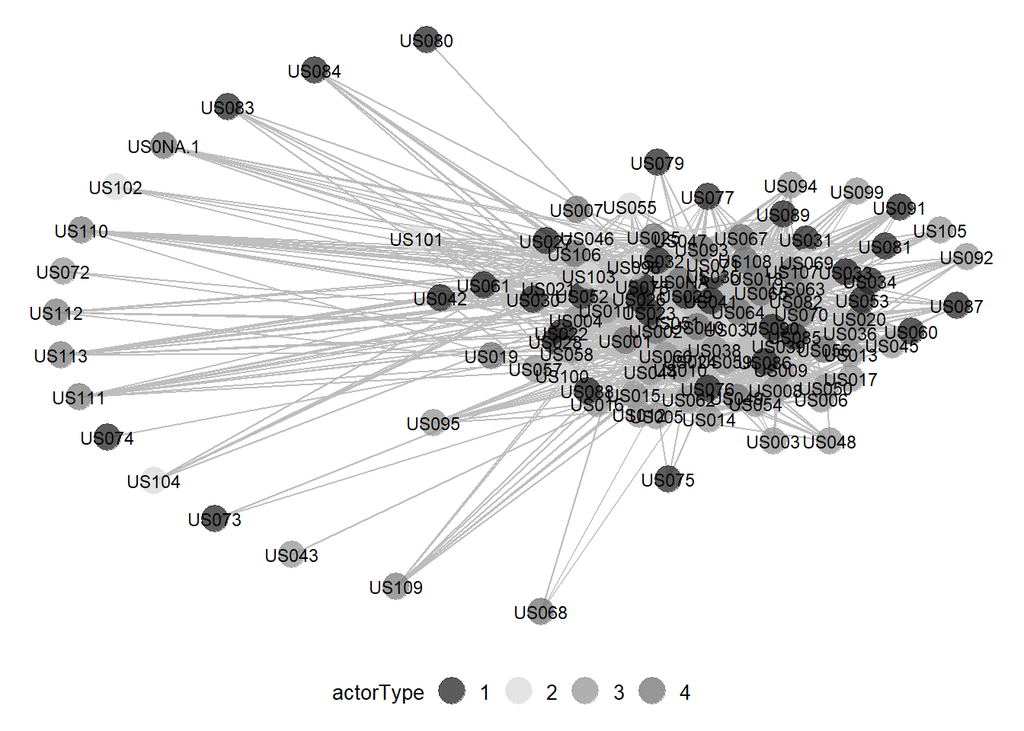

```r
# detach(package:igraph) # igraph will cause confusion with other packages, hence we need to detach it.

## HINT: Very likely you will have to install these packages --> Google them to understand what they do.

library(sna)
library(GGally)
library(network)
library(ggplot2)
library(RColorBrewer)
library(intergraph)
library(scales)

net <- network(coll.mat) # this is a different way to creat a matrix object (using the network package); check the class!

# To add attributes here:

att.usa$OT_BIG <- as.character(att.usa$OT_BIG)
net%v%"actorType" <- att.usa$OT_BIG

# Adjust your color palette (tip: https://colorbrewer2.org/#type=sequential&scheme=BuGn&n=3)!
# Actor type code: 1=GOVERNMENT, 2=SCIENCE, 3=BUSINESS, 4=CIVIL SOCIETY

# Exmple on how to create a color palette for the actor type variable

palette = c("1" = "#252525", "2" = "#d9d9d9",
             "3" ="#969696", "4" = "#737373")

# Adjust this code to your taste! If you don't know what to do, go and ask Dr. Google!

ggnet2(net, alpha = 0.75, label = TRUE, label.size = 3, mode = "kamadakawai",  node.size = 6, color = "actorType",
       edge.size = 0.4,
       color.legend = "actorType", edge.color = "grey", # maybe you have to adjust the name of the actorType variable here
       palette = palette,
       legend.size = 10, legend.position = "bottom")
```

```r
ggsave("Plots/my_xxx_network.png", width = 29, height = 18,  device = NULL, dpi = 300) # now save your graph to your working directory
```

## Solutions No. 1

1. Transform the **influence** matrix and the **science** matrix into igraph objects (i.e. igraph adjacency matrix).

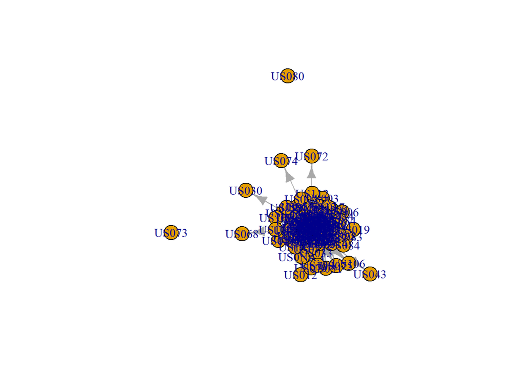

```r
inf.mat <- as.matrix(inf.usa)
inf.net <- graph.adjacency(inf.mat, mode="directed", diag=FALSE)
plot(inf.net)
```

```r
sci.mat <- as.matrix(sci.usa)
sci.net <- graph.adjacency(sci.mat, mode="directed", diag=FALSE)
# plot(sci.net) --> plotting takes forever
```

2. Describe in your own words **what these networks reflect**, i.e. what are the ties? How are the three networks linked (collaboration, influence and science)?

Tie: collaboration; Percieved influence; exchange of scientific knowledge; Nodes: Political actors

3. Which network has more **asymmetric dyads** and which more **mutual dyads** - the science network, the influence network, or the collaboration network? What does this mean?

```r
# dyads

dyad.census(inf.usa)
```

```
##      Mut Asym Null
## [1,] 240  857  919
```

```r
dyad.census(sci.usa)
```

```
##       Mut Asym Null
## [1,] 1545 3361 1422
```

```r
dyad.census(coll.usa)
```

```
##      Mut Asym Null
## [1,] 159  489 1368
```

Overall, it is striking that the networks have a different number of possible connections. Why is that?

Mutual dyads mean that a perceived relationship is returned. Hence, actor A perceives a collaborative relationship and actor B returns this perceptions. However, there are cases, where such a relationship is not returned.

4. What is the **average path length** per network? What is the **diameter**? Are there differences between the networks? What does this imply?

```r
# average path length

average.path.length(coll.net)
```

```
## [1] 1.996868
```

```r
average.path.length(inf.net)
```

```
## [1] 1.776453
```

```r
average.path.length(sci.net)
```

```
## [1] 1.468124
```

```r
diameter(coll.net)
```

```
## [1] 4
```

```r
diameter(inf.net)
```

```
## [1] 4
```

```r
diameter(sci.net)
```

```
## [1] 3
```

The science network has the shortest average path length and diameter. This is an indication that the network is “denser” than the others.

5. Look at the `att.usa` data frame and try to understand what all these variables mean. Then add the **actor type** and **name** to all networks. Can you guess what number reflects what actor type? What is the purpose of the actor type / attribute variables from a network analysis perspective?

org: Name of organisation ID: ID of organisation, also to anynomize; OT_BIG / OT_SUB: actor types OT_FUND: How an organization is funded OT_PEAK: is the organization a peak organization

G010 - G0113 –> these are belief variables

Learning: To understand a dataset needs a code book!!

7. **Bonus - exercise**: